# Exercise 4.2.2

W. Mangrobang

#### Run CHUNK 1 to be sure ggplot and the SOA mortality data are loaded.

```r
# CHUNK 1
library(ggplot2)
data.mortality <- read.csv("/Users/Werlindo/Dropbox/PACP/data/soa_mortality_data.csv")
names(data.mortality)
```

```
##  [1] "X"             "policy.number" "prodcat"       "issstate"
##  [5] "region"        "distchan"      "smoker"        "sex"
##  [9] "issage"        "duration"      "attage"        "uwkey"
## [13] "exposure_cnt"  "exposure_face" "actual_cnt"    "actual_face"
## [17] "expected_cnt"  "expected_face" "uwtype"        "resind_ind"
## [21] "year"          "test"
```

```r
str(data.mortality)
```

```
## 'data.frame':    500000 obs. of  22 variables:
##  $ X            : int  1 2 3 4 5 6 7 8 9 10 ...
##  $ policy.number: int  1247363 24011357 10700572 5361544 19634287 12025233 1613938 12020784 13884142 23782259 ...
##  $ prodcat      : Factor w/ 4 levels "TRM","UL","ULSG",..: 4 3 4 2 3 4 2 4 4 2 ...
##  $ issstate     : Factor w/ 53 levels "","AK","AL","AR",..: 44 12 8 29 33 50 21 49 37 26 ...
##  $ region       : Factor w/ 5 levels "Midwest","Northeast",..: 3 3 2 3 2 5 2 2 1 1 ...
##  $ distchan     : Factor w/ 4 levels "A","B","D","I": 1 1 1 4 4 1 1 1 4 1 ...
##  $ smoker       : Factor w/ 3 levels "N","S","U": 2 1 1 1 2 3 1 2 1 1 ...
##  $ sex          : Factor w/ 3 levels "F","M","U": 2 1 1 2 2 1 2 1 1 2 ...
##  $ issage       : int  34 55 58 70 65 21 39 35 71 34 ...
##  $ duration     : int  33 3 2 8 6 45 18 20 12 23 ...
##  $ attage       : int  66 57 59 77 70 65 56 54 82 56 ...
##  $ uwkey        : Factor w/ 14 levels "0bb0","0bb1",..: 13 13 5 13 13 13 1 13 7 13 ...
##  $ exposure_cnt : num  0.403 0.798 0.123 0.351 0.915 ...
##  $ exposure_face: num  2095 219399 2389 16131 411781 ...
##  $ actual_cnt   : int  0 0 0 0 0 0 0 0 0 0 ...
##  $ actual_face  : num  0 0 0 0 0 0 0 0 0 0 ...
##  $ expected_cnt : num  0.00438 0.00147 0.00017 0.00789 0.01856 ...
##  $ expected_face: num  22.79 403.7 3.32 362.96 8350.91 ...
##  $ uwtype       : Factor w/ 7 levels "GI","MP","NM",..: 3 4 2 1 4 3 2 3 2 3 ...
##  $ resind_ind   : Factor w/ 4 levels "A","F","N","R": 1 3 3 3 3 3 3 3 4 3 ...
##  $ year         : int  2009 2008 2010 2009 2007 2007 2007 2006 2009 2009 ...
##  $ test         : int  3 1 1 1 2 3 1 1 1 1 ...
```

#### Run CHUNK 2 to create a split box plot. For this I will select issue age (**issage**) as numeric variable and distribution channel (**distchan**) as categorical variable.

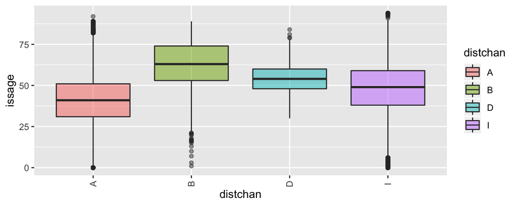

There does appears to be some sort of relationship. People who issue through channel B (bank/financial institutions) tend to be a little older.

#### Run CHUNK 3 to see what this looks like as stacked and split histograms.

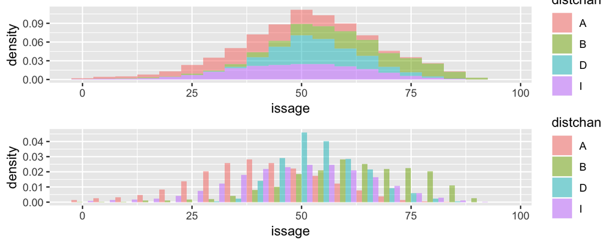

```r
# CHUNK 3
library(gridExtra)  #for gridArrange

## Stacked histogram
p1 <- ggplot(data = data.mortality, aes(issage, fill = distchan,
    ..density..)) + geom_histogram(binwidth = 5, alpha = 0.5)

## Split histogram
p2 <- ggplot(data = data.mortality, aes(issage, fill = distchan,
    ..density..)) + geom_histogram(binwidth = 5, alpha = 0.5,
    position = "dodge")
grid.arrange(p1, p2, ncol = 1)
```

Nothing stands out, too much.

Distribution channel was kind of interesting. Let’s seem if it has any relationships to any other categorical variables.

##### Run CHUNK 4 to build a stacked bar chart of distribution channel vs **region**.

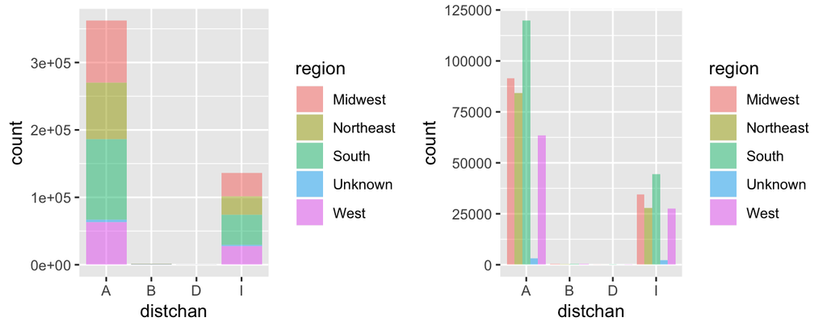

```r
# CHUNK 4
p1 <- ggplot(data = data.mortality, aes(x = distchan, fill = region)) +
    geom_bar(stat = "count", alpha = 0.5)
p2 <- ggplot(data = data.mortality, aes(x = distchan, fill = region)) +
    geom_bar(stat = "count", alpha = 0.5, position = "dodge")
grid.arrange(p1, p2, ncol = 2)
```

Interesting! It appears that for certain distribution channels (B,D => banks, direct), that region is not recorded. Also, looking at the dictionary there is mention of a code C for credit unions, but there is no data for that channel that I’ve seen. Not sure if that’s an error.

Double check.

#### Run CHUNK 4b for a pivot table.

```r
# CHUNK 4b
library(reshape)
cast(data.mortality, distchan ~ region)
```

|  | distchan | Midwest | Northeast | South | Unknown | West |
| --- | --- | --- | --- | --- | --- | --- |
| 1 | A | 91563 | 84118 | 119686 | 3172 | 63317 |
| 2 | B | 299 | 201 | 469 | 0 | 464 |
| 3 | D | 45 | 24 | 145 | 16 | 114 |
| 4 | I | 34457 | 27719 | 44369 | 2164 | 27658 |

That’s the actual issue, the number of policies sold through those channels are dwarfed relative to A,I (affiliated and independent agents), that it appears that there are none or close to none on the bar charts.

#### Run CHUNK 5 to see an example of a heat map. For this we will explore actual vs expected face value of claims.

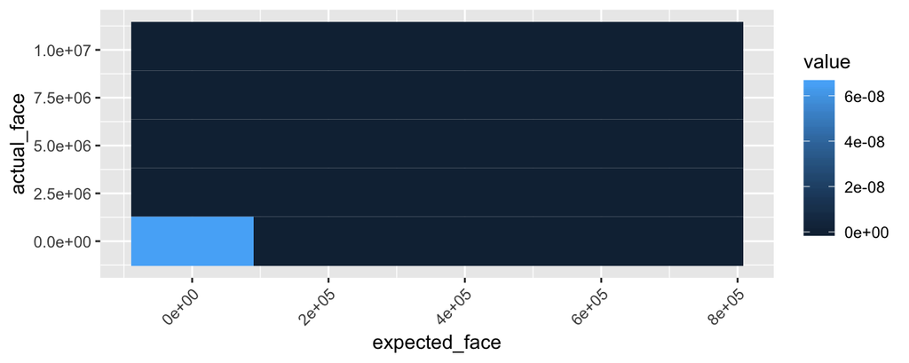

Very trivial result; most of the concentration is in the lower left section. In other words, None or very little policies with very low expected face but high actual, or vice versa. But at least it agrees with what general intuition would be.